# Zhang_Final Project

Catherine Zhang

2025-05-02

# How does the media frame vasectomy: a political issue, a gender issue, or a medical issue?

### ——A comparative content analysis on vasectomy reportings in United States and China

Catherine Yuxiao Zhang

Ph.D. student

University of Maryland Department of Communication

Email: zhangyx1@umd.edu

# Abstract

Vasectomy, a form of male contraception, shows distinct usage patterns in the U.S. and China. In the U.S., over 500,000 procedures occur annually, with a notable increase following the overturn of Roe v. Wade. In China, once widespread under the One-Child Policy, vasectomy rates sharply declined to fewer than 4,000 annually by 2019 after the policy ended.

This study investigates how mainstream online news media in the U.S. and China have set the public agenda regarding vasectomy between 2000 and 2025, analyzing gendered narratives and the politicization of reproductive issues in digital communication environments. Drawing upon agenda-setting theory and gender theory, the research employs a quantitative-dominant mixed-method content analysis —including sentiment analysis, keyword search, topic modeling and network analysis—to systematically examine English-language coverage from major news outlets such as The New York Times(nytimes.com), CNN(cnn.com), Fox News(foxnews.com), NBC(NBCNEWS.com), China Daily, People’s Daily, Global Times and South China morning post.

This study addresses three core research questions: (1) What issues (medical procedure, contraceptive decision-making, or political and policy contexts) are emphasized by the media in each country when covering vasectomies? (2) How do media outlets connect vasectomy reporting with significant political or legislative events, such as the overturning of Roe v. Wade in the U.S. or national population policy shifts in China? (3) What gendered narratives and emotional tones emerge in these media reports, and how might they reflect broader cultural differences concerning reproductive equality?

By offering cross-cultural insights, this study contributes to ongoing scholarly discussions regarding reproductive responsibility, media influence on public discourse, and gendered power dynamics. The findings offer practical implications for media practitioners and policymakers aiming to improve media literacy around reproductive issues and inform public communication strategies to promote gender equity in reproductive health contexts.

Keywords: Vasectomy, agenda-setting, media study, news, reproductive health, gender

# **Dataset Description**

**Data Source:** Nexis Uni

**Search Query:** “vasectomy or vasectomies”

**Date Range:** January 1, 2000 to December 31, 2025

**Language:** English

**Timestamp of Search:** 12 April 2025, 16:08

## **China Results Search Summary**

The search was limited to news from the region “China” (under the “News Search by Region: China” criteria).

**Filter Settings:** All Authors, All Companies, All Subjects, All Industries, and Source Type set to “All”.

**Source Location:** China

**Results Found:** 76 articles, which will all be used to conduct comparative analysis.

**Notes:** The query focused on the terms “vasectomy” or “vasectomies” within the specified date range with the language restriction set to English. Given the lower number of results, the Chinese dataset provides a relatively smaller sample reflecting how this topic is reported in the context of China.

## **United States Results Search Summary**

A separate search was conducted for the region “United States” (using the “News Search by Region: United States” criteria), with a broader specification for the source type.

**Filter Settings:** All Authors, All Companies, All Subjects, All Industries. The Source Type includes Newspapers, Web-based Publications, Industry Trade Press, Magazines & Journals, Aggregate News Sources, Law Reviews & Journals, and Legal News.

**Source Location:** United States

**Results Found:** 4,279 articles

**Sampling:** From these 4,279 U.S. search results, a simple random sampling procedure was employed to select 2,000 articles for detailed analysis. Specifically, each of the 4,279 articles was assigned a unique numerical identifier ranging from 1 to 4,279. Subsequently, a random number generation method was utilized via ChatGPT to produce 2,000 distinct integers within this range. The articles corresponding to these randomly generated numbers were then retrieved from Nexis Uni for further examination. This approach ensured both the randomness and representativeness (46.7% of the search results) of the sampled dataset.

**Notes:** This larger sample reflects a robust media environment covering the topic of vasectomies in the U.S. context, offering a diverse range of publication types.

**Overall Dataset Description:** The complete dataset comprises news articles about vasectomies captured from Nexis Uni covering a 25-year period. The U.S. data, with 4,279 results, is significantly larger than the China data (76 results); however, for analytical tractability, a random sample of 2,000 U.S. articles was selected. Both searches were restricted to articles in English, ensuring consistency in language across regions.

This dataset is valuable for quantitative and qualitative analysis, such as topic modeling or trend analysis over time, and provides a cross-regional comparison of media coverage on vasectomy-related news.

# **Research Questions and Codebook**

This content analysis addresses three broad research questions, each of which is further subdivided into more specific analytic questions:

#### **RQ1: What issues (medical procedure, contraceptive decision-making, or political and policy contexts) are emphasized by the media in each country when covering vasectomies?**

–Specifically, what percentage of media coverage from the U.S. and China primarily focuses on a) medical issues, b) contraceptive decision-making, or c) political/policy contexts?

**Theoretical framework:** Media frame and Agenda Setting

**Method:** Topic Modeling and KWIC analysis

The coding Scheme is adopted from Framing dimensions from Boydstun et al. (2014). I picked 3 categories to mainly focus:

1. Health and safety: health care, sanitation, public safety
2. Cultural identity: traditions, customs, or values of a social group in relation to a policy issue
3. Policy prescription and evaluation: discussion of specific policies aimed at addressing problems

Based on this definition of the different categories, I developed my own codebook:

**Medical Issues (coded as 1):** Articles primarily describing vasectomy procedures, safety, effectiveness, side effects, recovery periods, medical advice, and healthcare information. Articles falls into this category if the most frequent keywords are: procedure, safe, medical, health, recovery, surgery.

**Contraceptive Decision-Making (coded as 2):** Articles highlighting vasectomy as an individual or family planning decision, including discussion about personal choices, family negotiation, gender responsibility, and reproductive autonomy. Articles falls into this category if the most frequent keywords are: decision, choice, family planning, responsibility, gender equality, contraceptive.

**Political/Policy Context (coded as 3):** Articles primarily emphasizing vasectomy in the context of legal decisions (e.g., Roe v. Wade), population control policies, birth rates, government intervention, or political controversies. Articles falls into this category if the most frequent keywords are: roe v wade, supreme court, birth rate, population policy, abortion, political, policy, one child policy.

Note: I use topic modeling to identify high-frequency and contextually relevant words in my corpus first to decide 1. How many categories are there, and 2. Which keywords should be included in the each categories.

#### **RQ2: How do media outlets connect vasectomy reporting with significant political or legislative events, such as the overturning of Roe v. Wade in the U.S. or national population policy shifts in China?**

–Specifically, how frequently is the term “Roe v. Wade” mentioned in U.S. media coverage of vasectomy, and how frequently is the “national population policy” (or related terms) mentioned in Chinese media coverage of vasectomy?

**Method:** Keyword Frequency Analysis & Keyword Co-occurrence Analysis

**1. roe_mentions (Continuous)**

Definition: The number of times the phrase “roe vs. wade” or “roe” or “Roe v. Wade”, etc appears in an article.

Applicability: Only applies to U.S. articles.

Measurement: Count the occurrences using string matching with a case-insensitive regular expression for “roe v. wade”.

**2. population_policy_mentions (Continuous)**

Definition: The number of times phrases related to the national population policy (e.g., “population policy”) appear in an article.

Applicability: Only applies to Chinese articles.

Measurement: Count the occurrences using string matching with a case-insensitive regular expression for “population policy” (or similar variants as needed).

**3. A list of top 20 bigrams:** This will be used to figure out what’s the most frequently used word combanitions in both U.S. and China vasectomy reportings.

**4. A word cloud** will also be generated to see the top mentioned words.

#### **RQ3: What gendered narratives and emotional tones emerge in these media reports, and how might they reflect broader cultural differences concerning reproductive equality?**

–Specifically, how do sentiment scores derived from the AFINN lexicon differ between U.S. and Chinese media coverage of vasectomy, and what proportion of articles in each country can be classified as positive, neutral, or negative based on these scores?

**Method:** Sentiment Analysis

**1. Sentiment Category (Categorical)**

Definition: A classification of an article’s overall sentiment based on its computed AFINN Sentiment Score.

Categories & Criteria: Positive: sentiment_score > 0；Neutral: sentiment_score = 0；Negative: sentiment_score < 0

To complement topic modeling and deepen the interpretation of media narratives, sentiment analysis was employed to assess the emotional tone of vasectomy-related news coverage. By categorizing texts as positive, neutral, or negative in sentiment, this approach provides insight into how media outlets construct affective frames around key themes such as reproductive policy, medical decision-making, or gender responsibility. Sentiment analysis enhances the understanding of not only what topics are being discussed, but also how they are emotionally portrayed—whether vasectomy is framed as empowering, controversial, or stigmatized. This layer of analysis enables a comparative evaluation of the attitudinal stance embedded in U.S. and Chinese media discourse, revealing potential ideological or cultural divergences in reproductive health communication.

**In addition,** besides topic modeling, **keyword co-occurrence network analysis** was conducted to further explore relationships among terms within media coverage. This analysis visually illustrates how frequently specific keywords appear together, thereby revealing the structural associations and underlying discursive patterns within news narratives (Bail, 2016). By mapping keyword connections—such as the frequent co-occurrence of “policy” with “restriction” or “procedure” with “safety”—the analysis provides insights into how media outlets implicitly frame vasectomy-related discussions. Such visualization not only complements the findings from topic modeling by verifying topic coherence but also highlights subtle but meaningful differences in how distinct concepts are linked in U.S. and Chinese media contexts.

# **Results**

## **Load useful packages and datasets**

```r
library(tidyverse)
library(janitor)
library(striprtf)
library(dplyr)
library(readxl)
library(lubridate)
library(writexl)
library(tidytext)
library(stringr)
library(rio)
library(quanteda)
library(readtext)
```

```r
#impotying U.S. data
vasus <- read_excel("./dataframes/Results list us.xlsx",
    col_types = c("text", "date", "text",
        "text", "text", "numeric", "text",
        "numeric", "numeric", "text", "numeric",
        "text", "text", "text", "text", "text",
        "text", "numeric", "numeric", "numeric",
        "numeric"))

vasus <- janitor::clean_names(vasus)

nrow(vasus)
```

```
## [1] 2000
```

```r
ncol(vasus)
```

```
## [1] 21
```

```r
print(paste0("The number of rows in the dataset is ", nrow(vasus), " and the number of columns in the dataset is ", ncol(vasus)))
```

```
## [1] "The number of rows in the dataset is 2000 and the number of columns in the dataset is 21"
```

```r
#impotying China data
vascn <- read_excel("./dataframes/Results list cn.xlsx",
    col_types = c("text", "date", "text",
        "text", "text", "numeric", "text",
        "numeric", "numeric", "text", "numeric",
        "text", "text", "text", "text", "text",
        "text", "numeric", "numeric", "numeric",
        "numeric"))

vascn <- janitor::clean_names(vascn)

nrow(vascn)
```

```
## [1] 76
```

```r
ncol(vascn)
```

```
## [1] 21
```

```r
print(paste0("The number of rows in the dataset is ", nrow(vascn), " and the number of columns in the dataset is ", ncol(vascn)))
```

```
## [1] "The number of rows in the dataset is 76 and the number of columns in the dataset is 21"
```

## **Overall Statistical Description of the Datasets**

The overall statistical description of the dataset comes from Nexis Uni. I use R to regenerate some important visuals to better reflect the basic trands in each U.S. and Chinese dataset. The overall statistical descriptions I chose from Nexis Uni are: coverage over time, top publications covering these stories, top subjects mentioned in these stories.

### **1. The coverage of vasectomy over time**

#### **U.S. Dataset**

According to Nexis Uni, for the 4279 U.S. articles, the coverage of vasectomy over time can see as below:

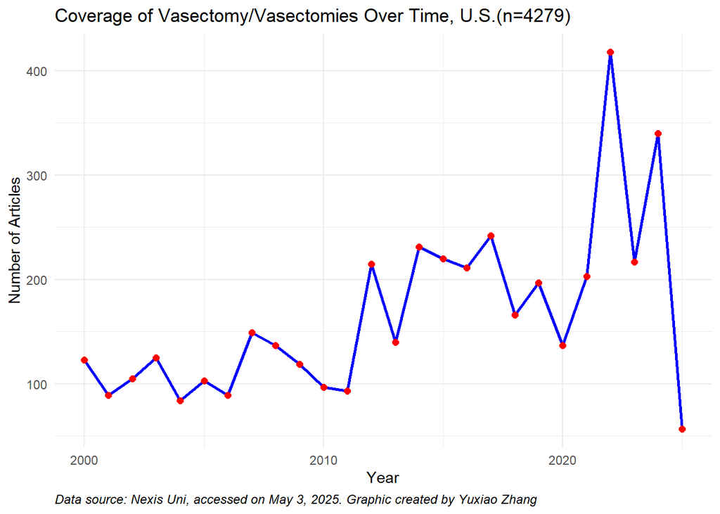

```r
library(readr)
Coverus <- read_csv("us_charts_nexis/CoverageoverTime_vasectomyvasectomies.csv")
Coverus <- janitor::clean_names(Coverus)
Coverus <- Coverus %>%
  mutate(covertime = as.Date(coverage_over_time))

p <- ggplot(Coverus, aes(x = covertime, y = coverage)) +
  geom_line(color = "blue", size = 1) +
  geom_point(color = "red", size = 2) +
  labs(title = "Coverage of Vasectomy/Vasectomies Over Time, U.S.(n=4279)",
       x = "Year",
       y = "Number of Articles",
        caption = "Data source: Nexis Uni, accessed on May 3, 2025. Graphic created by Yuxiao Zhang"
  ) +
  theme_minimal() +
  theme(
    plot.caption = element_text(hjust = 0, size = 9, face = "italic") )
p
```

This figure illustrates the temporal distribution of media coverage on vasectomy between 2000 and 2025. Coverage remained relatively low and stable from 2000 to 2010, followed by a moderate increase between 2011 and 2015. A notable surge occurred in 2022, aligning with the overturning of *Roe v. Wade*, indicating heightened media attention in response to political and legislative changes. The peak in 2022 was followed by a sharp fluctuation, suggesting a reactive media pattern tied to external socio-political events.

Here, I use the subtracted 2000 article dataset to visualize the coverage change over time again:

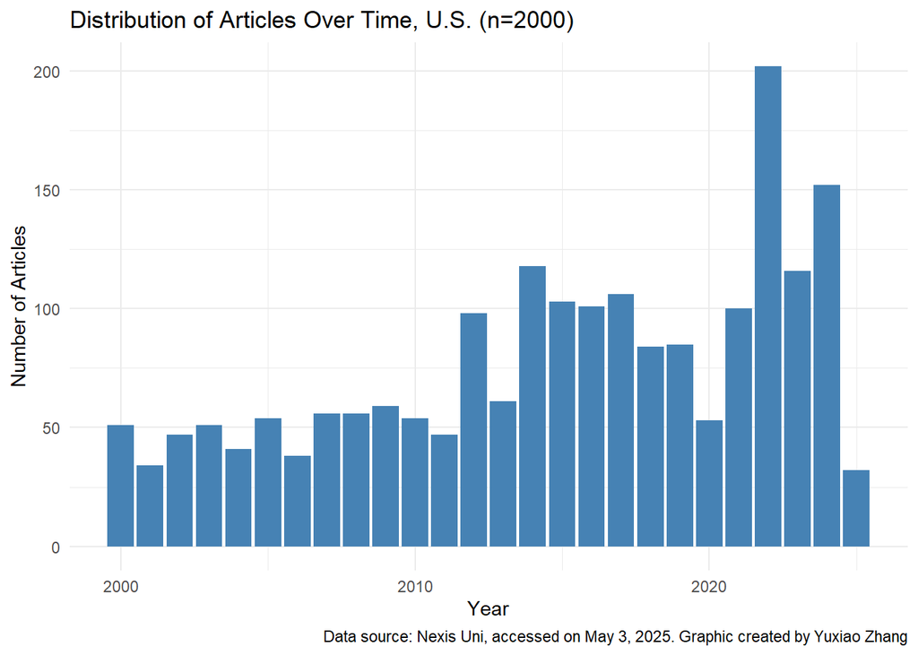

```r
vas_time <- vasus %>%
  mutate(year = year(published_date)) %>%
  group_by(year) %>%
  summarise(count = n()) %>%
  ungroup()

p2 <- ggplot(vas_time, aes(x = year, y = count)) +
  geom_bar(stat = "identity", fill = "steelblue") +
  labs(title = "Distribution of Articles Over Time, U.S. (n=2000)",
       x = "Year",
       y = "Number of Articles",
       caption = "Data source: Nexis Uni, accessed on May 3, 2025. Graphic created by Yuxiao Zhang") +
  theme_minimal()
print(p2)
```

The two charts shows similar pattern: Coverage remained relatively low and stable from 2000 to 2010, followed by a moderate increase between 2011 and 2015. A notable surge occurred in 2022, aligning with the overturning of *Roe v. Wade*. This further proves that the subtracted dataset fully represent the full 4279 dataset.

#### **China Dataset**

According to Nexis Uni, for the 76 China articles, the coverage of vasectomy over time can see as below:

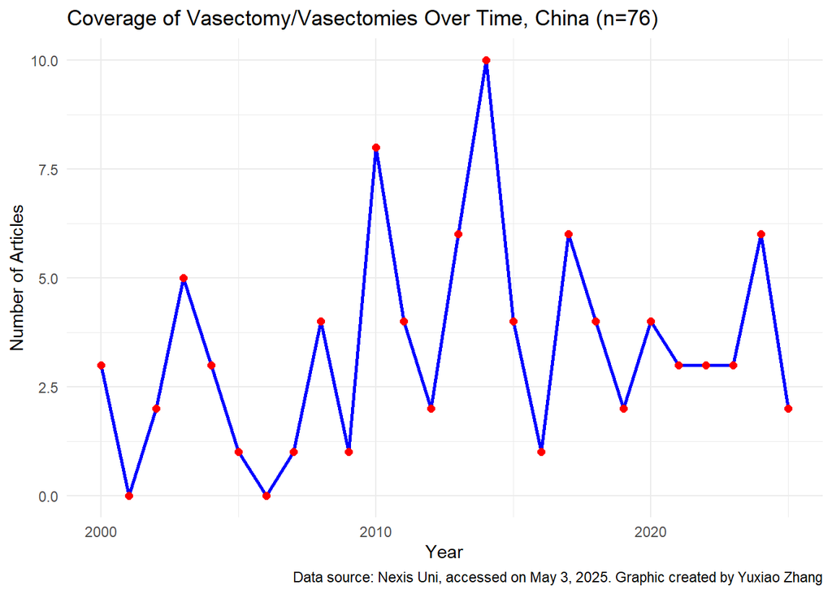

```r
Covercn <- read_csv("cn_charts_nexis/CoverageoverTime_vasectomyvasectomies.csv")
Covercn <- janitor::clean_names(Covercn)
Covercn <- Covercn %>%
  mutate(covertime = as.Date(coverage_over_time))

c <- ggplot(Covercn, aes(x = covertime, y = coverage)) +
  geom_line(color = "blue", size = 1) +
  geom_point(color = "red", size = 2) +
  labs(title = "Coverage of Vasectomy/Vasectomies Over Time, China (n=76)",
       x = "Year",
       y = "Number of Articles",
      caption = "Data source: Nexis Uni, accessed on May 3, 2025. Graphic created by Yuxiao Zhang") +
  theme_minimal()

c
```

China’s birth control policy has undergone three major shifts over the past decade. The first, the “Selective Two-Child Policy” introduced in 2013, allowed couples to have two children if one parent was an only child and marked the beginning of the end of the One-Child Policy, which had been in place for 35 years. This was followed by the “Universal Two-Child Policy” implemented in 2016, which extended the right to have two children to all couples. In 2021, the “Three-Child Policy” was launched in an effort to mitigate the challenges of an aging population and declining fertility rates.

While the dataset used in this study captures only English-language reporting by Chinese media—limiting its ability to reflect the full spectrum of domestic discourse—it nonetheless reveals meaningful trends. From 2000 to 2025, media coverage of vasectomy in China remains sparse and inconsistent. As shown in figure, the annual number of articles rarely exceeds single digits, with only a few notable peaks, such as in 2010 and 2014, which loosely align with the initial stages of policy loosening. Interestingly, coverage appears to increase slightly during periods when the government began promoting higher birth rates, suggesting a potential disconnect between state pronatalist goals and public attitudes.

The consistently minimal coverage further suggests that vasectomy has not been positioned as a significant topic in Chinese public discourse on fertility. This contrasts sharply with patterns observed in U.S. media, where reporting on vasectomy surged following the 2022 overturning of Roe v. Wade, reflecting a more responsive media environment shaped by reproductive rights debates. The persistent marginalization of vasectomy in Chinese media likely reflects both its politically sensitive nature and a broader cultural context in which pronatalist messaging and traditional gender norms continue to assign contraceptive responsibility primarily to women.

### **2. The top publications of vasectomy related coverage**

#### **U.S. Dataset**

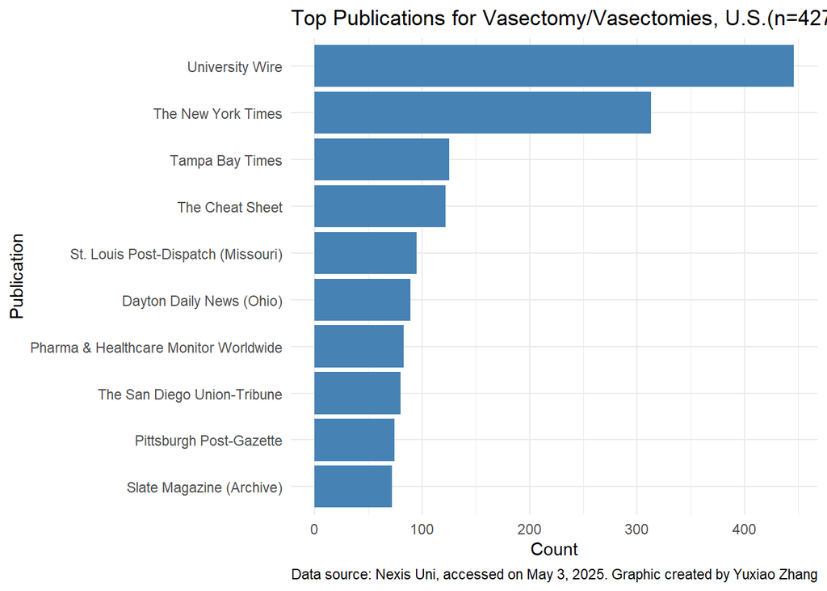

```r
top_pub <- read_csv("us_charts_nexis/TopPublications_vasectomyvasectomies.csv")

ggplot(top_pub, aes(x = reorder(Publication, Coverage), y = Coverage)) +
  geom_col(fill = "steelblue") +
  labs(title = "Top Publications for Vasectomy/Vasectomies, U.S.(n=4279)",
       x = "Publication",
       y = "Count",
        caption = "Data source: Nexis Uni, accessed on May 3, 2025. Graphic created by Yuxiao Zhang") +
  coord_flip() +
  theme_minimal()
```

#### **China Dataset**

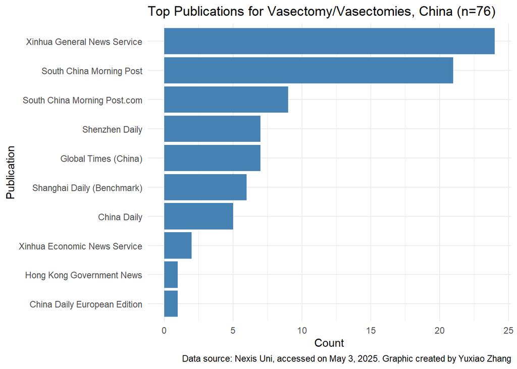

```r
top_pubcn <- read_csv("cn_charts_nexis/TopPublications_vasectomyvasectomies.csv")

ggplot(top_pubcn, aes(x = reorder(Publication, Coverage), y = Coverage)) +
  geom_col(fill = "steelblue") +
  labs(title = "Top Publications for Vasectomy/Vasectomies, China (n=76)",
       x = "Publication",
       y = "Count",
        caption = "Data source: Nexis Uni, accessed on May 3, 2025. Graphic created by Yuxiao Zhang") +
  coord_flip() +
  theme_minimal()
```

A comparison of top publication sources for vasectomy-related coverage reveals stark differences between Chinese and U.S. media environments. In China, English reporting is highly concentrated among a few official outlets, such as Xinhua News Service and China Daily, with overall coverage volumes remaining low. In contrast, U.S. media coverage is both more frequent and more diverse, encompassing national newspapers, local press, and specialized health industry publications. These patterns reflect broader structural differences in media systems: China’s state-led communication model limits the diversity and volume of discourse, while the U.S. media landscape facilitates more expansive and decentralized engagement with reproductive health topics.

## **Topic modeling**

**RQ1: What issues (medical procedure, contraceptive decision-making, or political and policy contexts) are emphasized by the media in each country when covering vasectomies?**

–Specifically, what percentage of media coverage from the U.S. and China primarily focuses on a) medical issues, b) contraceptive decision-making, or c) political/policy contexts?

### 1. Text compiler

#### U.S. Dataset

```r
# Set the paths
input_folder <- "./us_files_random_2000"
output_folder <- "./us_files_raw_text"

# Create output folder if it doesn't exist
if (!dir.exists(output_folder)) {
  dir.create(output_folder)
}

# Get a list of all .rtf files in the input folder
rtf_files <- list.files(path = input_folder, pattern = "\\.RTF$", full.names = TRUE)

# Convert each .rtf file to .txt
for (file in rtf_files) {
  # Extract the file name without extension
  file_name <- tools::file_path_sans_ext(basename(file))

  # Read the RTF content
  rtf_content <- read_rtf(file)

  # Create output file path
  output_file <- file.path(output_folder, paste0(file_name, ".txt"))

  # Write the content to a .txt file
  writeLines(rtf_content, output_file)

  # Print progress
  cat("Converted:", file, "to", output_file, "\n")
}

cat("Conversion complete!\n")
```

**Raw text compiler**

```r
#This creates an index with the file path to the stories. And then it compiles the stories into a dataframe
#####################
# Begin SM Code #####
#####################

###
# List out text files that match pattern .txt, create DF
###

#Adjust thisline for your file name
files <- list.files("./us_files_raw_text", pattern="*.txt") %>%
  as.data.frame() |>
  rename(filename = 1) |>
  #create an matching file name
  mutate(index = str_replace_all(filename, ".txt", "")) %>%
  mutate(index = tolower(gsub("[[:punct:][:space:]|]", "", index))) |>
  mutate(index = tolower(index)) |>
  mutate(index = str_sub(index, 1, 25)) |>
  distinct(index, .keep_all = TRUE)


#Join the file list to the index

final_data <- rio::import("./dataframes/Results list us.XLSX") |>
  clean_names() |>
   #create an matching file name
  mutate(index = tolower(gsub("[[:punct:][:space:]|]", "", title))) |>
  mutate(index = tolower(index)) |>
  mutate(index = str_sub(index, 1, 25)) |>
  distinct(index, .keep_all = TRUE)
```

**Check for duplicate entries**

```r
final_data |>
  count(title) |>
  arrange(desc(n))
```

```r
dupe_data <- rio::import("./dataframes/Results list us.XLSX") |>
  clean_names() |>
   #create an matching file name
  mutate(index = tolower(gsub("[[:punct:][:space:]|]", "", title))) |>
  mutate(index = tolower(index)) |>
  mutate(index = str_sub(index, 1, 25))
```

```r
dupe_data |>
  count(title) |>
  arrange(desc(n))
```

```r
final_index <- final_data |>
  inner_join(files, c("index")) |>
#you need the actual hard-coded path on this line below to the text
  mutate(filepath = paste0("./us_files_raw_text/", filename))

head(final_index)
```

**Fact Check**

```r
anti_final_index <- final_data |>
  anti_join(files, c("index"))
```

**Checking for duplicates**

```r
final_index |>
  count(title) |>
  arrange(desc(n))
```

**Text compiler**

```r
create_article_text <- function(row_value) {

  #row_value is the single argument that is passed to the function
  # Take each row of the dataframe
  temp <- final_index %>%
    slice(row_value)

  # Store the filename for  use in constructing articles dataframe
  temp_filename <- temp$filename

  # Create a dataframe by reading in lines of a given textfile
  # Add a filename column
  articles_df_temp <- read_lines(temp$filepath) %>%
    as_tibble() %>%
    mutate(filename = temp_filename)

  # Bind results to master articles_df
  # <<- returns to global environment
  articles_df <<- articles_df %>%
    bind_rows(articles_df_temp)
}

###
# Create elements needed to run function
###

# Create empty tibble to store results
articles_df <- tibble()
#running once to test
#create_article_text(2)
# Create an array of numbers to loop through, from 1 to the number of rows in our index dataframe
row_values <- 1:nrow(final_index)

###
# Execute function using lapply
# This loops through each row of the dataframe and append results to master file
###

lapply(row_values, create_article_text)

###
# Clean up articles_df and join to index dataframe
###

articles_df <- articles_df %>%
  select(filename, sentence=value) %>%
  inner_join(final_index)

#write.csv(articles_df, "./us_article_df.csv")
```

**I did same text compiling for the Chinese dataset.**

### **2. Topic Modeling**

#### **U.S. Data**

```r
# set options
options(stringsAsFactors = F)         # no automatic data transformation
options("scipen" = 100, "digits" = 4) # suppress math annotation
# load packages
here::here()
library(tidyverse)
library(tidytext)
library(rio)
library(readtext)
#topic modeling
library(quanteda)
library(tm)
library(topicmodels)
library(lda)
library(ldatuning)
# from tutorial packages
library(DT)
library(knitr)
library(kableExtra)
library(reshape2)
library(ggplot2)
library(wordcloud)
library(pals)
library(SnowballC)
library(flextable)
```

### **Import Data**

```r
#import text files that were compiled into a df
vasus_sent <- read_csv("./dataframes/us_article_df.csv")

#add a year column
vasus_sent <- vasus_sent %>%
  mutate(year = year(published_date))

vascn_sent <- read_csv("./dataframes/cn_article_df.csv")

#add a year column
vascn_sent <- vascn_sent %>%
  mutate(year = year(published_date))
```

```r
textdata <- vasus_sent %>%
  select(filename, sentence, year) %>%
  as.data.frame() %>%
  rename(doc_id = filename, text= sentence)

# load stopwords
english_stopwords <- readLines("https://slcladal.github.io/resources/stopwords_en.txt", encoding = "UTF-8")

custom_stop_words <- bind_rows(
  tibble(word = c("U.S.", "date", "english", "language", "usa", "copyright",
                  "publication", "reserved", "news", "newspaper","photograph","photo"),
         lexicon = rep("custom", 12)),
  stop_words
)
```

```r
# create corpus object
corpus_us <- Corpus(DataframeSource(textdata))
# Preprocessing chain
processedCorpus <- tm_map(corpus_us, content_transformer(tolower))
processedCorpus <- tm_map(processedCorpus, removeWords, english_stopwords)
processedCorpus <- tm_map(processedCorpus, removeWords, custom_stop_words$word)
processedCorpus <- tm_map(processedCorpus, removePunctuation, preserve_intra_word_dashes = TRUE)
processedCorpus <- tm_map(processedCorpus, removeNumbers)
processedCorpus <- tm_map(processedCorpus, stemDocument, language = "en")
processedCorpus <- tm_map(processedCorpus, stripWhitespace)
```

```r
#DTM: rows correspond to the documents in the corpus. Columns correspond to the terms in the documents. Cells correspond to the weights of the terms. (Girder)
# compute document term matrix with terms >= minimumFrequency
minimumFrequency <- 5
DTM <- DocumentTermMatrix(processedCorpus, control = list(bounds = list(global = c(minimumFrequency, Inf))))
# have a look at the number of documents and terms in the matrix
dim(DTM)
```

```
## [1] 120976  14040
```

```r
# due to vocabulary pruning, we have empty rows in our DTM
# LDA does not like this. So we remove those docs from the
# DTM and the metadata
sel_idx <- slam::row_sums(DTM) > 0
DTM <- DTM[sel_idx, ]
textdata <- textdata[sel_idx, ]
```

**Topic proportions over time**

We examine topics in the data over time by aggregating mean topic proportions per year. These aggregated topic proportions can then be visualized, e.g. as a bar plot.

```r
# number of topics
# K <- 20
K <- 6
# set random number generator seed
set.seed(9161)
#Latent Dirichlet Allocation, LDA
topicModel2 <- LDA(DTM, K, method="Gibbs", control=list(iter = 500, verbose = 25, alpha = 0.2))
tmResult <- posterior(topicModel2)
theta <- tmResult$topics
beta <- tmResult$terms
topicNames <- apply(terms(topicModel2, 10), 2, paste, collapse = " ")  # reset topicnames
```

**Mean topic proportions per year**

```r
# Step 1: Check dimensions
n_theta <- nrow(theta)
n_textdata <- length(textdata$year)

cat("Number of rows in theta: ", n_theta, "\n")
```

```
## Number of rows in theta:  91630
```

```r
cat("Number of documents in textdata: ", n_textdata, "\n")
```

```
## Number of documents in textdata:  91630
```

```r
# Check if textdata contains all the documents in theta
common_ids <- intersect(rownames(theta), textdata$doc_id) # Assuming textdata has a 'doc_id' column

# Filter textdata to include only the documents present in theta
textdata_filtered <- textdata[textdata$doc_id %in% common_ids, ]

# Check dimensions after filtering
n_textdata_filtered <- nrow(textdata_filtered)
cat("Number of documents in filtered textdata: ", n_textdata_filtered, "\n")
```

```
## Number of documents in filtered textdata:  91630
```

```r
# Ensure the lengths match now
if (n_theta != n_textdata_filtered) {
  stop("The number of rows in 'theta' still does not match the length of 'textdata_filtered$year'.")
}

# Align rownames of theta with filtered textdata
theta_aligned <- theta[rownames(theta) %in% textdata_filtered$doc_id, ]

# Optional: Verify the order of documents
if (!all(rownames(theta_aligned) == textdata_filtered$doc_id)) {
  # If the order doesn't match, reorder one to match the other
  textdata_filtered <- textdata_filtered[match(rownames(theta_aligned), textdata_filtered$doc_id), ]
}

# Ensure they are now aligned and can be combined
if (!all(rownames(theta_aligned) == textdata_filtered$doc_id)) {
  stop("The document IDs still do not match. Please check the data alignment.")
}

# Step 2: Combine data
topic_data <- data.frame(theta_aligned, year = textdata_filtered$year)

# Step 3: Aggregate data
topic_proportion_per_year <- aggregate(. ~ year, data = topic_data, FUN = mean)


# get mean topic proportions per decade
# topic_proportion_per_decade <- aggregate(theta, by = list(decade = textdata$decade), mean)
# set topic names to aggregated columns
colnames(topic_proportion_per_year)[2:(K+1)] <- topicNames
# reshape data frame
vizDataFrame <- melt(topic_proportion_per_year, id.vars = "year")
```

```r
#enframe(): Converts a named list into a dataframe.
topics <- enframe(topicNames, name = "number", value = "text") %>%
  unnest(cols = c(text))

topics
```

```
## # A tibble: 6 × 2
##   number  text
##   <chr>   <chr>
## 1 Topic 1 abort health women peopl plan care law govern servic countri
## 2 Topic 2 women patient contracept vasectomi birth control pregnanc studi healt…
## 3 Topic 3 time day children peopl famili life love feel live told
## 4 Topic 4 univers time york compani john citi michael edit david march
## 5 Topic 5 word length  right newstex content inform court employe provid law
## 6 Topic 6 special ave bodi surgeri document fairfax rockvill diseas arlington b…
```

**Review the topics and determine a 1-2 word label after reading the source documents.** To achieve this, I used the code below to extract the top 10 articles associated with each topic. I then reviewed these articles to identify key similarities and differences, which allowed me to validate and assign a concise 1–2 word label that best captures the essence of each topic.

**Topic 1 - abort health women peopl plan care law govern servic countri**

```r
theta2 <- as.data.frame(theta)

topic1 <- theta2 %>%
  rownames_to_column(var = "file") |>
  mutate(file = str_remove(file, "^X"),
         line = str_extract(file, "(?<=\\.txt)\\.\\d+")) |>
  mutate(file = str_remove(file, "\\.\\d+$")) |>
  rename(topic1 = '1') |>
  top_n(20, topic1) |>
  arrange(desc(topic1)) |>
  select(file, line, topic1)
```

These articles share a focus on how vasectomy is framed within broader debates about gender roles, reproductive rights, and state control. They highlight how male sterilization is politicized—used symbolically in legislation, population policies, or as a measure of gendered responsibility in contraception.

**Topic 2 - women patient contracept vasectomi birth control pregnanc studi health procedur**

```r
topic2 <- theta2 %>%
  rownames_to_column(var = "file") |> # putting the rownames into a new column called file
  mutate(file = str_remove(file, "^X"),  # Remove leading 'X'
         line = str_extract(file, "(?<=\\.txt)\\.\\d+")) |>   # Extract number after .txt
  mutate(file = str_remove(file, "\\.\\d+$")) |>
  rename(topic2 = '2') |>
  top_n(20, topic2) |>
  arrange(desc(topic2)) |>
  select(file, line, topic2)
```

Most articles focus on issues of reproductive autonomy and gender equity. They highlight how structural or psychological factors—such as coercion, trauma, or population control policies—impact individuals’ access to and control over contraceptive decisions.

**Topic 3 - time day children peopl famili life love feel live told**

```r
topic3 <- theta2 %>%
  rownames_to_column(var = "file") |>
  mutate(file = str_remove(file, "^X"),
         line = str_extract(file, "(?<=\\.txt)\\.\\d+")) |>
  mutate(file = str_remove(file, "\\.\\d+$")) |>
  rename(topic3 = '3') |>
  top_n(20, topic3) |>
  arrange(desc(topic3)) |>
  select(file, line, topic3)
```

Across these articles, vasectomy is rarely discussed in medical or policy terms; instead, it appears almost exclusively as a rhetorical device to express a point or create narrative tension. Often used humorously, it serves as a symbolic marker of male reproductive control. This may reflect that in cultural storytelling, male contraception remains more of a punchline than a subject of serious reflection.

**Topic 4 - univers time york compani john citi michael edit david march**

```r
topic4 <- theta2 %>%
  rownames_to_column(var = "file") |>
  mutate(file = str_remove(file, "^X"),
         line = str_extract(file, "(?<=\\.txt)\\.\\d+")) |>
  mutate(file = str_remove(file, "\\.\\d+$")) |>
  rename(topic4 = '4') |>
  top_n(20, topic4) |>
  arrange(desc(topic4)) |>
  select(file, line, topic4)
```

Similar to topic 3, these articles focus on cultural narrative, where vasectomy is rarely framed as a responsible reproductive choice; instead, it frequently appears as a source of humor, surprise, or dramatic irony. This may reflect the broader tendency to marginalize male contraception and treat it as a symbolic or comedic device rather than a serious subject.

**Topic 5 - word length right newstex content inform court employe provid law**

```r
topic5 <- theta2 %>%
  rownames_to_column(var = "file") |>
  mutate(file = str_remove(file, "^X"),
         line = str_extract(file, "(?<=\\.txt)\\.\\d+")) |>
  mutate(file = str_remove(file, "\\.\\d+$")) |>
  rename(topic5 = '5') |>
  top_n(20, topic5) |>
  arrange(desc(topic5)) |>
  select(file, line, topic5)
```

These articles revolve around how legal frameworks—whether criminal law or reproductive rights—shape, restrict, or provoke personal bodily decisions, highlighting tensions between institutional authority and individual autonomy.

**Topic 6 - special ave bodi surgeri document fairfax rockvill diseas arlington bethesda**

```r
topic6 <- theta2 %>%
  rownames_to_column(var = "file") |>
  mutate(file = str_remove(file, "^X"),
         line = str_extract(file, "(?<=\\.txt)\\.\\d+")) |>
  mutate(file = str_remove(file, "\\.\\d+$")) |>
  rename(topic6 = '6') |>
  top_n(20, topic6) |>
  arrange(desc(topic6)) |>
  select(file, line, topic6)
```

These articles present vasectomy as a medical procedure within the context of clinical care and professional specialization. They frame vasectomy primarily as a routine, medically managed procedure rather than a cultural or political statement.

*Add Categories to each topic*

```r
vizDataFrame <- vizDataFrame %>%
  mutate(variable = str_to_lower(variable),variable = str_squish(variable)) %>%
  mutate(category = case_when(
    variable == "abort health women peopl plan care law govern servic countri" ~ "Politics",
    variable == "women patient contracept vasectomi birth control pregnanc studi health procedur" ~ "Gender Equality",
    variable == "time day children peopl famili life love feel live told" ~ "Symbolic Meaning/Satire",
    variable == "univers time york compani john citi michael edit david march" ~ "Rhetoric and Humorous Meaning",
    variable == "word length right newstex content inform court employe provid law" ~ "Law and Rights",
    variable == "special ave bodi surgeri document fairfax rockvill diseas arlington bethesda" ~ "Medical",
    TRUE ~ "other"
  ))
```

**Sample Fact Check and Validate Topics**

| Nu mber | Keywords | Catergory |
| --- | --- | --- |
| Topic 1 | abort health women peopl plan care law govern servic countri | Politics |
| Topic 2 | women patient contracept vasectomi birth control pregnanc studi health procedur | Gender Equality |
| Topic 3 | time day children peopl famili life love feel live told | Symbolic Meaning/Satire |
| Topic 4 | univers time york compani john citi michael edit david march | Rhetoric & Humorous Meaning |
| Topic 5 | word length right newstex content inform court employe provid law | Law and Rights |
| Topic 6 | special ave bodi surgeri document fairfax rockvill diseas arlington bethesda | Medical |

**For politics**

```r
politics <- theta2 %>%
  #renaming for a general topic
  rename(politics = '1') %>%
  top_n(20, politics) %>%
  arrange(desc(politics )) %>%
  select(politics )

# Apply rownames_to_column
politics <- tibble::rownames_to_column(politics , "story_id")

politics$story_id <- gsub("X", "", politics$story_id)

head(politics$story_id, 20)
```

```
##  [1] "The.gender.entrapment.of.neoliberal.development.txt.20"
##  [2] "Gates.of.Vienna.News.Feed.10_4_2021.txt.256"
##  [3] "The.Swazi.17.txt.55"
##  [4] "Symbolic.Legislation.Will.Not.Get.Us.Free.txt.14"
##  [5] "Oregon.Will.Protect.Reproductive.Health.Care.When.Hospitals.Merge.txt.29"
##  [6] "Oregon.Will.Protect.Reproductive.Health.Care.When.Hospitals.Merge.txt.16"
##  [7] "Gay.Marriage.Is.the.Best.Traditionalists.Could.ve.Hoped.For.txt.19"
##  [8] "AMA.HOD_.Delegates.advocate.medical.service..health.system.reforms.resolutions.with.little.debate.txt.9"
##  [9] "The.Best._Human.Nature_.Sex.Stories.of.2007.txt.18"
## [10] "Global.NGOs.Use.Your.Tax.Dollars.to.Manipulate.Poor.Nations..Birth.Rates.txt.7"
## [11] "Dugger.s.theorem_.the.free.market.is.impossible_.remarks.upon.receiving.the.Veblen.Commons.Award.txt.66"
## [12] "Two.Christian.Conservatives.Debate.the.Merits.of.Voting.for.Kamala.Harris.txt.60"
## [13] "Working.in.Clark.County_.East.Vancouver.Catherine.Dole_.Assistant.Health.Center.Manager.at.Vancouver.txt.12"
## [14] "The.Iran.Deal.Wasn.t.Revolutionary.txt.9"
## [15] "THE.ADVERSARY.txt.67"
## [16] "Gates.of.Vienna.News.Feed.8_28_2014.txt.264"
## [17] "GOP.opposition.to.universal.suffrage.a.threat.to.democracy.txt.6"
## [18] "Editorial_.Don.t.defund.Planned.Parenthood.txt.8"
## [19] "OPINION_.Is.the.America.we.know.a.modern.day.theocracy_...The.Seahawk.txt.64"
## [20] "Oregon.Will.Protect.Reproductive.Health.Care.When.Hospitals.Merge.txt.27"
```

**Visualizting Topic modeling of U.S. sample**

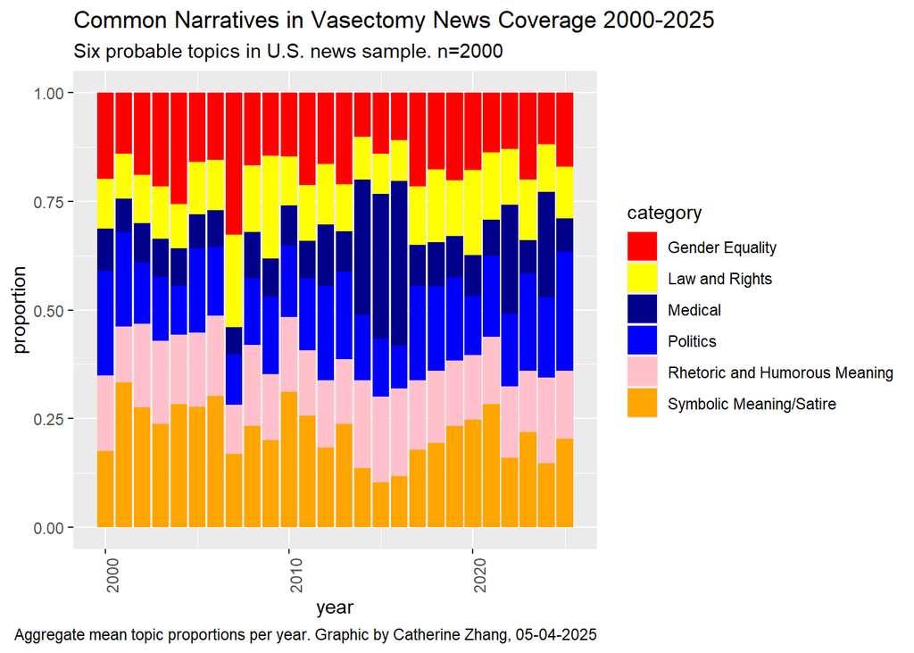

```r
ggplot(vizDataFrame, aes(x=year, y=value, fill=category)) +
  geom_bar(stat = "identity") + ylab("proportion") +
  scale_fill_manual(values = paste0(alphabet(20), "FF"), name = "year") +
  theme(axis.text.x = element_text(angle = 90, hjust = 1)) +
   scale_fill_manual(values=c("red",
                              "yellow",
                              "darkblue",
                              "blue",
                              "pink",
                              "orange")) +
  labs(title = "Common Narratives in Vasectomy News Coverage 2000-2025",
       subtitle = "Six probable topics in U.S. news sample. n=2000",
       caption = "Aggregate mean topic proportions per year. Graphic by Catherine Zhang, 05-04-2025")
```

```r
#ggsave(here::here("./Figure_US_topics_04_04_2025.png"),device = "png",width=9,height=6, dpi=800)
```

#### A similar topic modeling was done for the china coverage

Here’s the visualization of China topics

| T opic 1 | health reproduct public depart surgeri govern famili transplant sexual medic | State Regul ation/policy |
| --- | --- | --- |
| T opic 2 | contracept vasectomi women male effect control sperm hospit condom research | Medical development |
| T opic 3 | famili plan children popul birth child govern coupl zhang vasectomi | Reproductive Governance |
| T opic 4 | morn classif reserv bodi publish inform daili time media monday | Symbolic Masculinity/ Reproductive Re sponsibility |

[figure not shown]

### **United States: Common Narratives in Vasectomy News Coverage (2000–2025)**

Meanwhile, **“Medical”** (dark blue) and **“Politics”** (blue) continue to be present across the timeline, affirming that vasectomy remains a topic situated at the intersection of public health and political discourse.

### **China: Common Narratives in Vasectomy News Coverage (2000–2025)**

The topic modeling figure for China coverage is based on a sample of 76 Chinese media articles, identifies four dominant topics. In the earlier years, **“Reproductive Governance”** (red) and **“Medical Development”** (purple) were the most prominent, suggesting that vasectomy was initially framed primarily as a state-driven policy tool and a clinical procedure.

Over time, the proportion of **“Symbolic Masculinity/Reproductive Responsibility”** (green) has notably increased—particularly after 2015—indicating a growing shift in how male contraception is perceived, with more stories portraying vasectomy as a personal or ethical gesture (e.g., “getting snipped for love” or “being a responsible partner”).

The **“State Regulation/Policy”** topic (blue) remains relatively stable, suggesting that the narrative of state control continues to serve as a persistent backdrop. Overall, Chinese media coverage has gradually evolved from a technocratic and regulatory discourse toward one that increasingly integrates cultural and gendered perspectives, though the transition remains cautious and uneven.

Because the sample size of China’s media coverage is very small, the topic categories identified are limited and should be interpreted with caution. Additionally, this dataset includes only English-language reports from Chinese media, which may introduce bias. However, manual fact-checking and coding revealed that many Chinese articles focus on **negative portrayals of forced vasectomy**, framing it as a tool of state-led fertility control. Some pieces presented conflicting views—for example, while one article reported on cases of forced vasectomy, another denied such occurrences. In recent years, coverage has shifted slightly toward depicting vasectomy as a **voluntary birth control option** and discussing the **development of male contraceptive technologies**.

Together, the charts illustrate how cultural, political, and media environments shape the narrative roles vasectomy plays—either as a serious act of reproductive responsibility or as a symbolic object within social and political commentary.

## Keyword Frequency & Co-occurrence Analysis (Bigrams)

#### **RQ2: How do media outlets connect vasectomy reporting with significant political or legislative events, such as the overturning of Roe v. Wade in the U.S. or national population policy shifts in China?**

–Specifically, how frequently is the term “Roe v. Wade” mentioned in U.S. media coverage of vasectomy, and how frequently is the “national population policy” (or related terms) mentioned in Chinese media coverage of vasectomy?

### Produce a list of top 20 bigrams

**U.S. Data: Bigram of the full text**

```r
#Tokenize the sentence column
vasus_bigram <- str_replace_all(vasus_sent$sentence, "- ", "")
vasus_bigram_df <- tibble(vasus_bigram,)

vasus_tokenized <- vasus_bigram_df %>%
  unnest_tokens(word,vasus_bigram)

#remove stop words
data(stop_words)
vasus_tokenized <- vasus_tokenized %>%
  anti_join(stop_words, by = c("word" = "word")) %>%
  filter(word != "temp_file") %>%
  filter(word != "stories_corpus") %>%
  filter(!grepl('[0-9]', word))

usbigrams <- vasus_bigram_df %>%
  unnest_tokens(bigram, vasus_bigram, token="ngrams", n=2)

#Filter out stop words.

usbigrams1 <- usbigrams %>%
  separate(bigram, c("word1", "word2"), sep = " ")

usbigrams2 <- usbigrams1 %>%
  filter(!word1 %in% stop_words$word) %>%
  filter(!word2 %in% stop_words$word) %>%
  filter(!is.na(word1), !is.na(word2)) %>%
  filter(!str_detect(word1, "^\\d+$")) %>%
  filter(!str_detect(word2, "^\\d+$")) %>%
  filter(!word1 %in% c("nw", "york","times","ave","reserved","st","load","date")) %>%
  filter(!word2 %in% c("nw", "york","times","ave","reserved","st","load","date"))

# word count and top 30 bigram
usbigram3 <- usbigrams2 %>%
  count(word1, word2, sort = TRUE)%>%
  top_n(30, n)

usbigram3
```

```
## # A tibble: 30 × 3
##    word1         word2             n
##    <chr>         <chr>         <int>
##  1 birth         control        1861
##  2 health        care            935
##  3 planned       parenthood      724
##  4 chevy         chase           711
##  5 family        planning        528
##  6 supreme       court           502
##  7 dr            arlington       452
##  8 authoritative content         450
##  9 newstex       authoritative   450
## 10 dr            fairfax         422
## # ℹ 20 more rows
```

**U.S. Data, bigram of the hlead column that contains headlines and ledes.**

```r
#Tokenize the hlead column
vasus_bigram <- str_replace_all(vasus$hlead, "- ", "")
vasus_bigram_df <- tibble(vasus_bigram,)

vasus_tokenized <- vasus_bigram_df %>%
  unnest_tokens(word,vasus_bigram)

#remove stop words
data(stop_words)
vasus_tokenized <- vasus_tokenized %>%
  anti_join(stop_words, by = c("word" = "word")) %>%
  filter(word != "temp_file") %>%
  filter(word != "stories_corpus") %>%
  filter(!grepl('[0-9]', word))

usbigrams <- vasus_bigram_df %>%
  unnest_tokens(bigram, vasus_bigram, token="ngrams", n=2)

#Filter out stop words.

usbigrams1 <- usbigrams %>%
  separate(bigram, c("word1", "word2"), sep = " ")

usbigrams2 <- usbigrams1 %>%
  filter(!word1 %in% stop_words$word) %>%
  filter(!word2 %in% stop_words$word) %>%
  filter(!is.na(word1), !is.na(word2))

# word count and top 20 bigram
usbigram3 <- usbigrams2 %>%
  count(word1, word2, sort = TRUE)%>%
  top_n(20, n)

usbigram3
```

```
## # A tibble: 20 × 3
##    word1              word2                  n
##    <chr>              <chr>              <int>
##  1 birth              control              440
##  2 supreme            court                138
##  3 planned            parenthood           134
##  4 health             care                 123
##  5 family             planning              81
##  6 male               birth                 81
##  7 reproductive       health                54
##  8 abortion           rights                53
##  9 control            pill                  53
## 10 health             insurance             53
## 11 nick               cannon                53
## 12 cheat              sheet                 50
## 13 vasectomy          reversal              50
## 14 male               contraceptive         49
## 15 sheet              http                  49
## 16 reproductive       rights                47
## 17 http               www.cheatsheet.com    46
## 18 www.cheatsheet.com delivered             46
## 19 march              madness               38
## 20 women's            health                38
```

These two bigrams helped to identify several important top mentioned keywords combanitions that we can further do a keyword search and KWIC on. Note that the bigrams generated by using hlead column is better than using the full text, since the full text contains too much noise and copyright related informations that are hard to filter out.

Based on the two bigrams, several important keywords (and combantions) are:

1. birth control(n=1861, n=440)
2. supreme court (n=502, n=138)
3. health care(n=935, n=123)
4. family planning (n=528, n=81)
5. planned parenthood(n=724, n=134)
6. reproductive health (n=351, n=54)
7. male birth (n=81)
8. abortion rights (n=53)

The bigram results reveal several key patterns. First, core reproductive themes are prominent in both the full texts and ledes, with high-frequency pairs such as “birth control,” “health care,” and “planned parenthood” indicating that vasectomy is often discussed within the broader context of public health and fertility regulation. Second, legal and political associations are evident, as “supreme court” consistently ranks among the top terms in both datasets—highlighting the legal framing of vasectomy, especially in relation to landmark cases like Roe v. Wade. Third, the lead sentences tend to emphasize values and conflict more directly than full texts, with combinations such as “male birth,” “abortion rights,” “control pill,” suggesting that leads are more rhetorically charged and designed to engage readers through controversy or moral framing.

I chose “birth control”, “supreme court”, and “women’s health” and as Keywords to plot the frequency over year. These 3 keywords represent the 3 categories that I’m interested in: vasectomy as a medical procedure, vasectomy as a political issue, or vasectomy as a gender issue.

*Birth control*

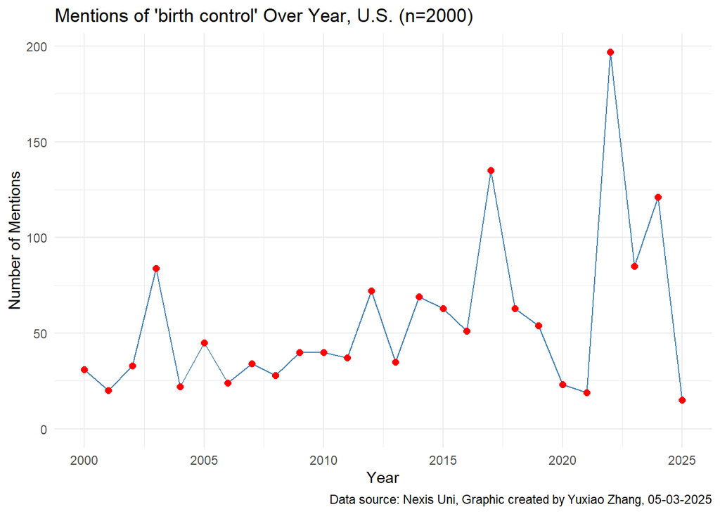

```r
supreme_court_mention <- vasus_sent %>%
  mutate(mention_sup = str_detect(str_to_lower(sentence), "birth control"))

mention_counts <- supreme_court_mention %>%
  group_by(year) %>%
  summarise(mentions = sum(mention_sup, na.rm = TRUE)) %>%
  arrange(year)

ggplot(mention_counts, aes(x = year, y = mentions)) +
  geom_line(color = "steelblue") +
  geom_point(color = "red", size = 2) +
  labs(title = "Mentions of 'birth control' Over Year, U.S. (n=2000)",
       x = "Year",
       y = "Number of Mentions",
       caption = "Data source: Nexis Uni, Graphic created by Yuxiao Zhang, 05-03-2025") +
  theme_minimal()
```

*supreme court*

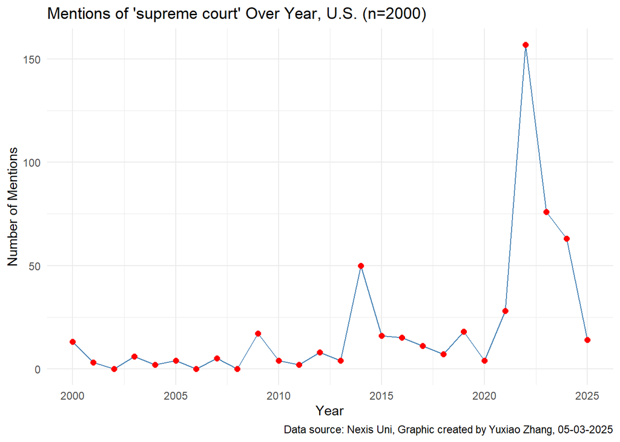

```r
supreme_court_mention <- vasus_sent %>%
  mutate(mention_sup = str_detect(str_to_lower(sentence), "supreme court"))

mention_counts <- supreme_court_mention %>%
  group_by(year) %>%
  summarise(mentions = sum(mention_sup, na.rm = TRUE)) %>%
  arrange(year)

ggplot(mention_counts, aes(x = year, y = mentions)) +
  geom_line(color = "steelblue") +
  geom_point(color = "red", size = 2) +
  labs(title = "Mentions of 'supreme court' Over Year, U.S. (n=2000)",
       x = "Year",
       y = "Number of Mentions",
      caption = "Data source: Nexis Uni, Graphic created by Yuxiao Zhang, 05-03-2025") +
  theme_minimal()
```

“Supreme court” mentions follow a similar trajectory, with a sharp rise in 2022, reflecting heightened media coverage of judicial influence on reproductive rights. This suggests that vasectomy is increasingly discussed in legal-political contexts, not merely as a private medical choice.

*women’s health*

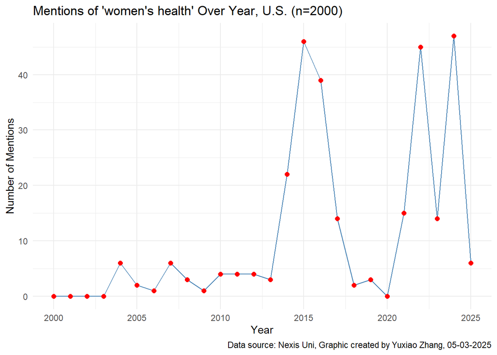

```r
supreme_court_mention <- vasus_sent %>%
  mutate(mention_sup = str_detect(str_to_lower(sentence), "women'?s health"))

mention_counts <- supreme_court_mention %>%
  group_by(year) %>%
  summarise(mentions = sum(mention_sup, na.rm = TRUE)) %>%
  arrange(year)

ggplot(mention_counts, aes(x = year, y = mentions)) +
  geom_line(color = "steelblue") +
  geom_point(color = "red", size = 2) +
  labs(title = "Mentions of 'women's health' Over Year, U.S. (n=2000)",
       x = "Year",
       y = "Number of Mentions",
      caption = "Data source: Nexis Uni, Graphic created by Yuxiao Zhang, 05-03-2025") +
  theme_minimal()
```

“Women’s health” mentions are lower overall but surge in 2014–2015 and again in 2022–2024, reflecting moments of intensified debate about gender equity and healthcare access. These upticks indicate that while vasectomy is framed less often in gendered terms, moments of political controversy draw more attention to broader reproductive health discourse—including the roles and responsibilities of men.

Together, these trends illustrate that media narratives around vasectomy shift in response to legal rulings and sociopolitical debate, reinforcing its position at the intersection of medicine, law, and gender justice.

## KWIC search

keywords: vasectomy，vasectomies，reproductive，male contraception, male birth, birth control

```r
vasuskwic <- vasus_sent %>%
  mutate(file_id = as.numeric(factor(title)))

vasuskwic  <- vasuskwic %>%
  mutate(unique_file_id = paste0(file_id, "_", row_number()))

index <- vasus %>%
  mutate(file_id = as.numeric(factor(title)))
# Now create the corpus with the new unique identifier
kwic_corpus <- corpus(vasuskwic, text_field = "sentence",
                       docid_field = "unique_file_id")

# Tokenize the corpus：a word per row
vasuskwic_tokens <- tokens(kwic_corpus)
```

```r
kwic_results <- kwic(
  vasuskwic_tokens,
  phrase(c("vasectomy","vasectomies","reproductive","male contraception", "male birth","birth control")),
  window = 50, valuetype = "regex"
) %>%
  as.data.frame()
```

```r
#Strips out unique file name from article index
kwic_results <- kwic_results |>
    mutate(matchrow = str_extract(docname, "^[^_]+[^_]+"))

metadata <- index

# Join KWIC results with metadata
metadata$file_id <- as.character(metadata$file_id)

kwic_with_metadata <- kwic_results %>%
  inner_join(metadata, by = c("matchrow"="file_id")) |>
  distinct(docname, .keep_all= TRUE) |>
  select(matchrow, title, published_date, publication_location, publication, publication_type_1, length, section, word_count, countries, byline, agg_copyright, cite, company, headline, hlead, pub_copyright, show, term, ticker, from, to, pre, keyword, post, pattern, docname)
```

```r
#Eliminate duplication
kwic_with_metadata_clean  <- kwic_with_metadata  %>%
  distinct(docname, pre, keyword, post,published_date, publication_location, publication) %>%
  rename('Beginning of Passage' = pre, 'End of Passage' = post, Location = publication_location, Newspaper = publication, Date =  published_date)

kwic_with_metadata_csv <- kwic_with_metadata_clean  %>%
  add_column(Code = NA) %>%
  add_column(Comments = NA) %>%
  select(docname, Newspaper, Date, 'Beginning of Passage', keyword, 'End of Passage', Code, Comments)

#write_csv(kwic_with_metadata_csv, "kwic_with_metadata_us.csv")
```

**A collocation wordcloud based on KWIC search**

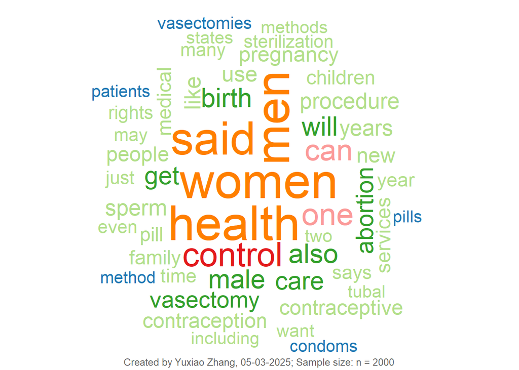

```r
library(wordcloud)

kwic_data <- read_csv("./dataframes/kwic_with_metadata_us.csv")
kwic_context <- paste(kwic_data$`Beginning of Passage`, kwic_data$`End of Passage`)
corpus <- Corpus(VectorSource(kwic_context))

corpus_clean <- corpus %>%
  tm_map(content_transformer(tolower)) %>%
  tm_map(removePunctuation) %>%
  tm_map(removeNumbers) %>%
  tm_map(removeWords, stopwords("en")) %>%
  tm_map(stripWhitespace)

dtm <- TermDocumentMatrix(corpus_clean)
m <- as.matrix(dtm)
word_freq <- sort(rowSums(m), decreasing = TRUE)
word_freq_df <- data.frame(word = names(word_freq), freq = word_freq)

set.seed(123)
wordcloud(words = word_freq_df$word,
          freq = word_freq_df$freq,
          min.freq = 2,
          max.words = 50,
          random.order = FALSE,
          colors = brewer.pal(8, "Paired"))
mtext("Created by Yuxiao Zhang, 05-03-2025; Sample size: n = 2000",
      side = 1, line = 4, cex = 0.8, col = "gray40")
```

**China Dataset**

I did a bigram on China dataset and a KWIC search as well.

```
## # A tibble: 37 × 3
##    word1        word2               n
##    <chr>        <chr>           <int>
##  1 family       planning          154
##  2 birth        control            72
##  3 hong         kong               48
##  4 surgery      transplantation    43
##  5 reproductive health             34
##  6 pregnancy    childbirth         28
##  7 human        reproductive       27
##  8 reproductive technology         27
##  9 obstetrics   gynecology         26
## 10 social       media              25
## # ℹ 27 more rows
```

The most frequent bigrams — family planning (154 mentions) and birth control (72 mentions) — indicate that vasectomy is commonly discussed within the context of population policy and public health frameworks, aligning with China’s long-standing discourse on reproductive management. Also, terms like surgery transplantation, reproductive health, obstetrics gynecology, and reproductive technology suggest that coverage is often technical and biomedical in nature. This reflects a clinical framing where vasectomy is treated as a medical intervention rather than a gendered or controversial choice.

Unlike U.S. coverage that often includes Supreme Court, abortion rights, or gender equality, this list lacks strong legal or rights-based vocabulary, highlighting a different cultural and political framing. While terms like reproductive health and pregnancy childbirth appear, there is little evidence of discourse around male responsibility, gender equity, or masculinity, suggesting that vasectomy is not widely framed in relation to male reproductive agency.

**A collocation wordcloud based on KWIC search for China reporting**

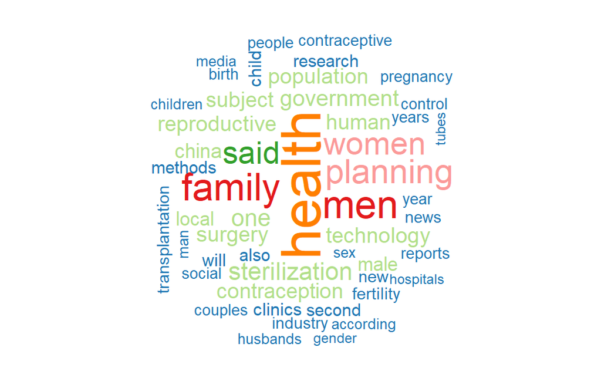

Collocation wordcloud created by Yuxiao Zhang, 05-03-2025; Sample size: n = 76

**Comparative analysis of the two collocation wordclouds:**

1. Technical vs. Symbolic Framing:

In the Chinese word cloud, terms like health, family, planning, sterilization, surgery, transplantation, and contraception dominate. This indicates a framing of vasectomy primarily as a biomedical and demographic tool, embedded in public health discourse and family planning policies.

2. Gendered Language:

The Chinese word cloud does include men, women, and husbands, but these terms are mostly placed in relation to institutional roles (e.g., government, clinics, subject). Male agency in vasectomy appears neutral or administrative.

3. State vs. Rights Orientation:

The Chinese coverage features collocations such as government, subject, population, and local, underscoring a state-driven population governance narrative.

The U.S. discourse, meanwhile, heavily emphasizes individual rights, legal frameworks, and identity politics—vasectomy becomes a site of resistance, protest, or personal choice.

To sum up, Chinese vasectomy reporting tends to be clinical, policy-oriented, and state-centered, while U.S. coverage often frames vasectomy as a contested site of gender politics and individual rights. The comparison illustrates how the same medical procedure can be discursively shaped by vastly different cultural and political environments.

## Sentiment Analysis

#### **RQ3: What gendered narratives and emotional tones emerge in these media reports, and how might they reflect broader cultural differences concerning reproductive equality?**

–Specifically, how do sentiment scores derived from the AFINN and NRC lexicon differ between U.S. and Chinese media coverage of vasectomy, and what proportion of articles in each country can be classified as positive, neutral, or negative based on these scores?

```r
#Tokenize sentences

vas_scent_df <- tibble(sentence = str_replace_all(vasus_sent$sentence, "- ", ""),
                       year = vasus_sent$year)

vas_tokenized <- vas_scent_df %>%
  unnest_tokens(word, sentence)

#remove stop words

data(stop_words)

vas_tokenized <- vas_tokenized %>%
  anti_join(stop_words, by = c("word" = "word")) %>%
  filter(word != "temp_file", word != "stories_corpus") %>%
  filter(!grepl("[0-9]", word))
```

#### Overall Sentiment analysis by year using AFINN

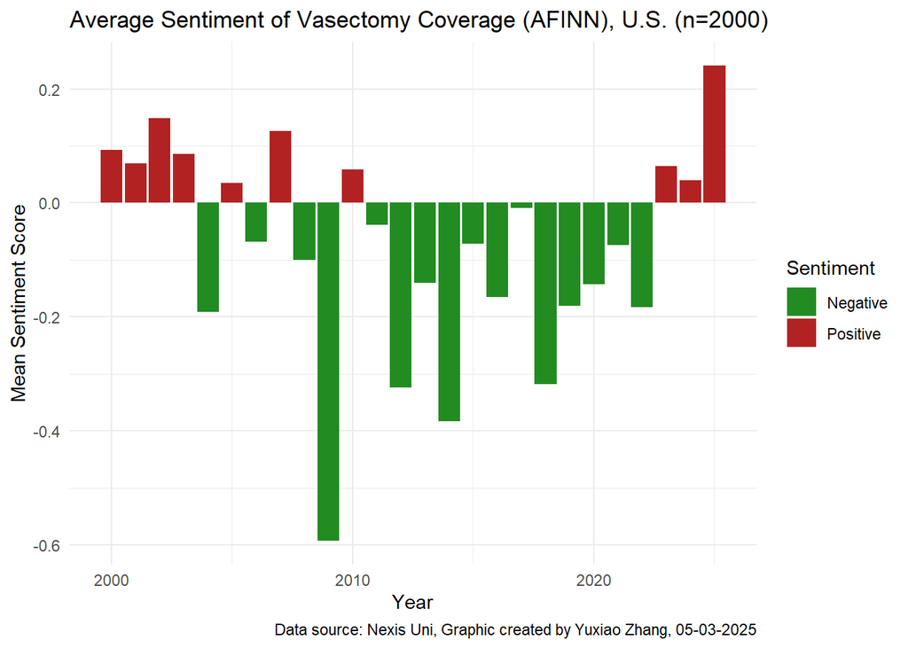

```r
#install.packages("textdata")
nrc_sentiments <- get_sentiments("nrc")
afinn_sentiments <- get_sentiments("afinn")

afinn_sentiment <- vas_tokenized %>%
  inner_join(afinn_sentiments, by = "word")

afinn_yearly <- afinn_sentiment %>%
  group_by(year) %>%
  summarise(mean_sentiment = mean(value, na.rm = TRUE))

ggplot(afinn_yearly, aes(x = year, y = mean_sentiment, fill = mean_sentiment > 0)) +
  geom_col() +
  scale_fill_manual(values = c("TRUE" = "firebrick", "FALSE" = "forestgreen"),
                    labels = c("Negative", "Positive")) +
  labs(title = "Average Sentiment of Vasectomy Coverage (AFINN), U.S. (n=2000)",
       x = "Year",
       y = "Mean Sentiment Score",
       fill = "Sentiment",
       caption = "Data source: Nexis Uni, Graphic created by Yuxiao Zhang, 05-03-2025") +
  theme_minimal()
```

This chart shows U.S. media coverage of vasectomy fluctuates over time, with predominantly negative sentiment from around 2005 to the early 2020s. A noticeable uptick in positive sentiment appears post-2022, potentially linked to sociopolitical responses following the overturning of Roe v. Wade.

This trend suggests that discussions of vasectomy have become more favorable or normalized in recent years, possibly as part of a broader public discourse on male reproductive responsibility.

#### Multi-facet sentiment analysis using NRC

```r
nrc_sentiments %>%
  count(sentiment, sort = TRUE)

sentiments_all <- vas_tokenized %>%
  inner_join(nrc_sentiments, by = "word")

vas_tokenized %>%
  inner_join(nrc_sentiments) %>%
  count(word, sort = TRUE)

sentiments_all %>%
  count(sentiment, sort = TRUE)

over_sen <-sentiments_all %>%
  count(sentiment, sort = TRUE)
```

**NRC Sentiment Distribution**

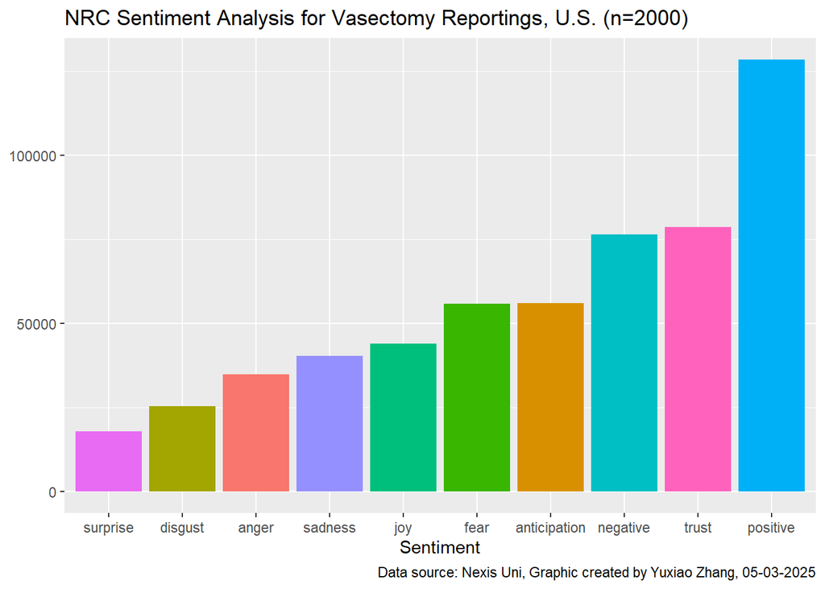

```r
ggplot(over_sen, aes(x = reorder(sentiment,n), y = n, fill = sentiment)) +
  geom_col(show.legend = FALSE) +
  labs(title = "NRC Sentiment Analysis for Vasectomy Reportings, U.S. (n=2000)",
       x = "Sentiment",
       y = NULL,
       caption = "Data source: Nexis Uni, Graphic created by Yuxiao Zhang, 05-03-2025")
```

The positive sentiment category dominates the NRC classification, followed by trust, negative, and anticipation. Emotional tones like fear, sadness, and anger are also substantially present, indicating that vasectomy is sometimes framed within contexts of anxiety or conflict.

**Top Words by NRC Emotion**

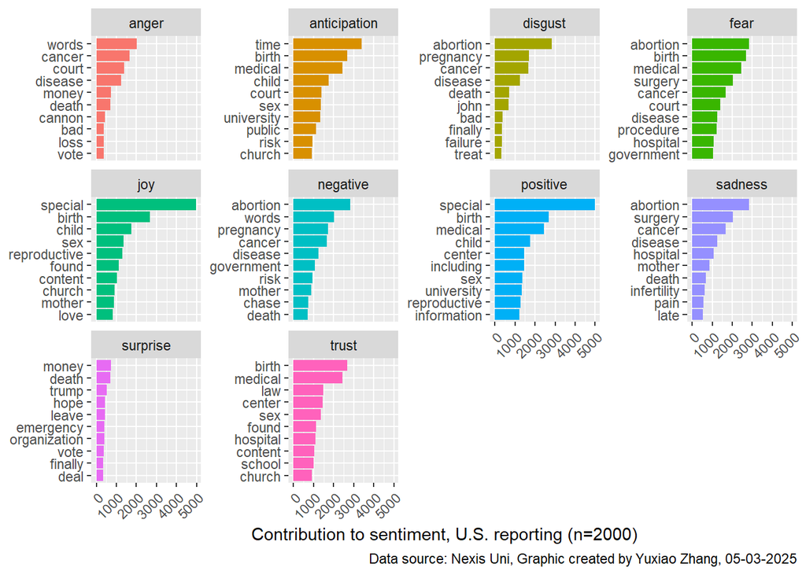

```r
sentiments_all %>%
  count(sentiment, word) %>%
  group_by(sentiment) %>%
  slice_max(n, n = 10) %>%
  ungroup() %>%
  mutate(word = reorder_within(word, n, sentiment)) %>%
  ggplot(aes(n, word, fill = sentiment)) +
  geom_col(show.legend = FALSE) +
  facet_wrap(~sentiment, scales = "free_y") +
  scale_y_reordered() +
  labs(x = "Contribution to sentiment, U.S. reporting (n=2000)",
       y = NULL,
       caption = "Data source: Nexis Uni, Graphic created by Yuxiao Zhang, 05-03-2025")+ theme(axis.text.x = element_text(angle = 45, hjust = 1))
```

**NRC Word Cloud**

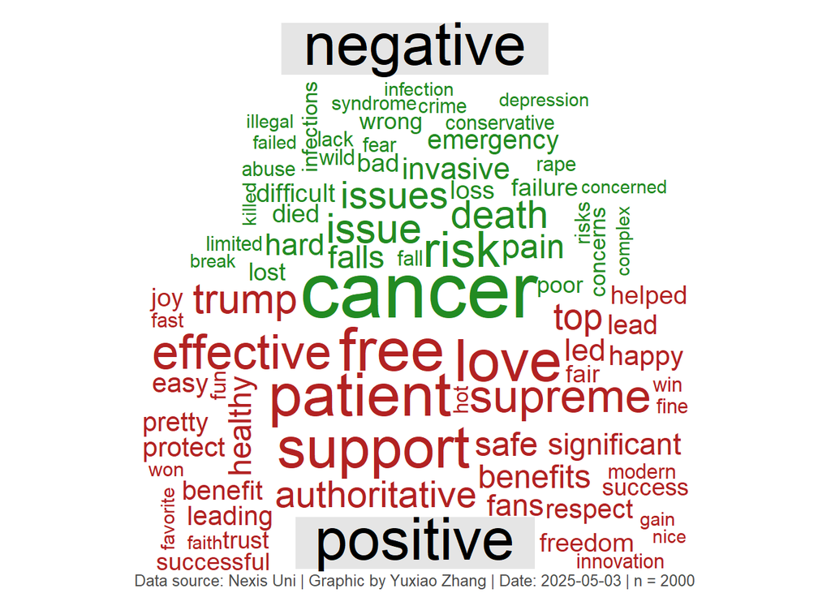

```r
library(reshape2)

vas_tokenized %>%
  inner_join(get_sentiments("bing")) %>%
  count(word, sentiment, sort = TRUE) %>%
  acast(word ~ sentiment, value.var = "n", fill = 0) %>%
  comparison.cloud(colors = c("forestgreen", "firebrick"), max.words = 100)
mtext("Data source: Nexis Uni | Graphic by Yuxiao Zhang | Date: 2025-05-03 | n = 2000",
      side = 1,       # Bottom of plot
      line = 4,       # Distance from plot (adjust as needed)
      cex = 0.8,      # Font size
      col = "gray30")
```

The word cloud juxtaposes positive words (e.g., free, support, effective) with negative ones (e.g., cancer, risk, death). This reflects the dual framing of vasectomy either as empowering and safe, or as invasive and risky — depending on context.

These patterns suggest that U.S. media increasingly links vasectomy to gender equality, particularly through framing it as a responsible male choice in reproductive planning. The presence of strong emotional language also implies that vasectomy discourse is entangled with broader cultural tensions around reproductive rights, masculinity, and health policy.

However, the NRC and AFINN lexicons are context-agnostic — they may misclassify words like “cancer” or “abortion” as inherently negative, even in neutral or informative reporting. Thus we need to cross check this analysis with the KWIC analysis.

#### For China dataset:

**Overall Sentiment analysis by year using AFINN**

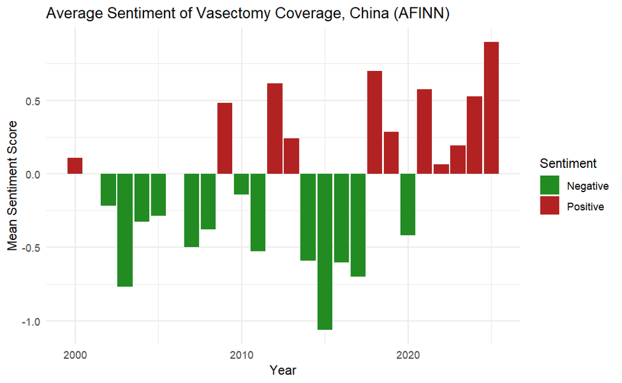

n=76, Data source: Nexis Uni, Graphic created by Yuxiao Zhang, 05-03-2025

**Multi-facet sentiment analysis using NRC**

**NRC Aggregate Sentiment Bar Chart**

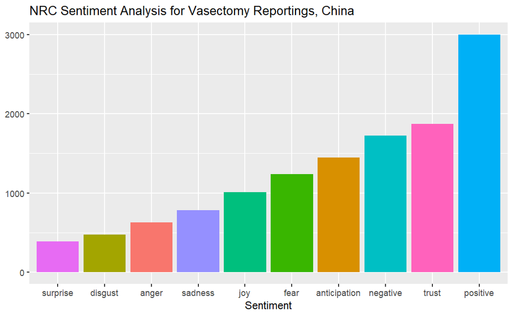

n=76, Data source: Nexis Uni, Graphic created by Yuxiao Zhang, 05-03-2025

Top Emotions: “Positive,” “trust,” “negative,” and “anticipation” lead. Compared to U.S., anger and disgust are less prominent.

**NRC Top Words by Emotion**

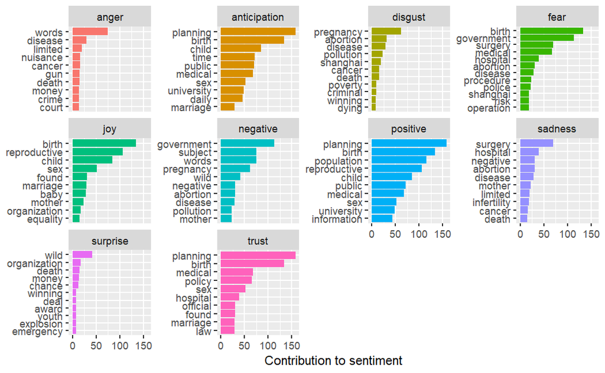

n=76, Data source: Nexis Uni, Graphic created by Yuxiao Zhang, 05-03-2025

This shows frequent use of “planning,” “birth,” “policy,” “public” points to a collective/public health discourse. Negative Words are “Pollution,” “disease,” “abortion,” but not as emotionally volatile as in U.S. Joyful words includes “marriage,” “equality,” “child”—indicating state-affirming, normative gender values.

**NRC Wordcloud**

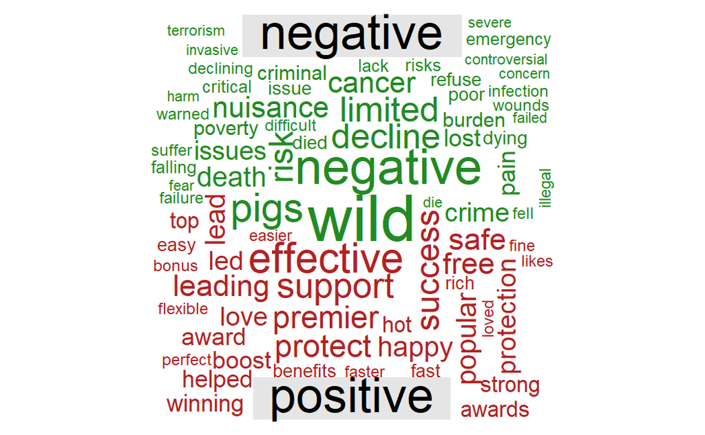

n=76, Data source: Nexis Uni, Graphic created by Yuxiao Zhang, 05-03-2025

Positive Words: “Effective,” “support,” “success,” “safe” Negative Words: “Wild,” “nuisance,” “death,” “decline” This shows framing might be policy-oriented and pragmatic, less emotionally polarized.

# **Conclusion**

This study investigated how mainstream online news media in the United States and China frame vasectomy, particularly examining whether it is primarily portrayed as a medical, gender-related, or political issue. Across a comparative content analysis of English-language media from 2000 to 2025, key findings indicate distinct framing differences influenced by cultural, political, and media contexts in each country.

First, U.S. media frequently frame vasectomy in political and gendered terms, particularly in response to legal and legislative developments like the overturning of *Roe v. Wade*. Topic modeling and sentiment analysis reveal a shift over time toward more serious and positive framings, portraying vasectomy as a symbol of male reproductive responsibility and gender equity. However, a novel and persistent feature of U.S. reporting is its rhetorical or satirical use of vasectomy—as a punchline, metaphor, or symbolic gesture—particularly in cultural commentary. This tendency points to an ambivalence in how male contraception is publicly discussed, simultaneously recognized as important yet often trivialized in tone.

Second, while Chinese media coverage remains relatively sparse and policy-oriented, especially when compared to the robust and diverse U.S. dataset, topic modeling shows a meaningful evolution. Over time, especially after 2015, Chinese reporting has increasingly incorporated narratives of symbolic masculinity and reproductive responsibility. Stories portraying vasectomy as a personal or ethical gesture—such as “getting snipped for love” or being a “responsible partner”—indicate a growing recognition of male agency in contraception. Unlike the often humorous tone in U.S. media, these narratives in Chinese outlets tend to be presented in a more formal, normative manner, aligning with broader state discourses on demographic change and family planning ethics.

In sum, this study finds that vasectomy is not merely a medical procedure, but a contested cultural symbol shaped by divergent national media environments. In the U.S., it is framed through a complex mix of political, legal, gendered, and symbolic discourses—often laced with humor or satire. In China, while reporting remains more clinical and policy-rooted, recent years have shown a cautious but growing integration of symbolic and ethical dimensions of male contraception. These findings highlight how reproductive responsibility—and particularly male roles within it—is not only biologically enacted but also socially narrated, revealing deep-seated cultural attitudes toward gender, autonomy, and the body.

# Reference

An, S.-K., & Gower, K. K. (2009). How do the news media frame crises? A content analysis of crisis news coverage. Public Relations Review, 35(2), 107–112. https://doi.org/10.1016/j.pubrev.2009.01.010

Bail, C. A. (2016). Combining natural language processing and network analysis to examine how advocacy organizations stimulate conversation on social media. Proceedings of the National Academy of Sciences, 113(42), 11823–11828. https://doi.org/10.1073/pnas.1607151113

Card, D., Boydstun, A. E., Gross, J. H., Resnik, P., & Smith, N. A. (2015). The Media Frames Corpus: Annotations of Frames Across Issues. In C. Zong & M. Strube (Eds.), Proceedings of the 53rd Annual Meeting of the Association for Computational Linguistics and the 7th International Joint Conference on Natural Language Processing (Volume 2: Short Papers) (pp. 438–444). Association for Computational Linguistics. https://doi.org/10.3115/v1/P15-2072

Kwak, H., An, J., & Ahn, Y.-Y. (2020). A Systematic Media Frame Analysis of 1.5 Million New York Times Articles from 2000 to 2017. Proceedings of the 12th ACM Conference on Web Science, 305–314. https://doi.org/10.1145/3394231.3397921